# **Lista 2**

Por vezes, mesmo fazendo seleção de colunas e filtragem de linhas, o tamanho final da tabela extrapola o espaço disponível na memória *RAM*. Nesses casos, precisamos realizar as operações de manipulação fora do `R`, em um banco de dados ou em um sistema de armazenamento distribuído. Outras vezes, os dados já estão armazenados em algum servidor/*cluster* e queremos carregar para o `R` parte dele, possivelmente após algumas manipulações.

Nessa lista repetiremos parte do que fizemos na Lista 1. Se desejar, use o gabarito da Lista 1 emsubstituição à sua própria solução dos respectivos itens.

# **Questão 1: Criando bancos de dados.**

## **a)** Crie um banco de dados `SQLite` e adicione as tabelas consideradas no item **2a)** da Lista 1.

```r
p_load(RSQLite)
SQL <- dbConnect(RSQLite::SQLite(), "dfDB.db")
dbWriteTable(SQL, "df_dataDB", df,overwrite = TRUE)
```

## **b)** Refaça as operações descritas no item **2b)** da Lista 1 executando códigos `sql` diretamente no bancode dados criado no item **a)**. Ao final, importe a tabela resultante para o `R`. Não é necessário descrever novamente o que são as regiões de saúde.

Atenção:Pesquise e elabore os comandos `sql` sem usar a ferramenta de tradução de `dplyr` para `sql`.

```r
qvrs <- dbGetQuery(SQL,"
                   SELECT regiao_saude,
                   COUNT(*) AS 'quantidade'
                   FROM df_dataDB
                   GROUP BY regiao_saude
                   ORDER BY quantidade DESC
                   ;")

dbWriteTable(SQL, "qvrs", qvrs,overwrite = TRUE)

dbGetQuery(SQL, 'SELECT * FROM qvrs LIMIT 5')

mediana <- dbGetQuery(SQL,"
                      SELECT AVG(quantidade) AS 'mediana'
                      FROM (
                      SELECT quantidade
                      FROM qvrs
                      ORDER BY quantidade
                      LIMIT 2
                      OFFSET (SELECT (COUNT(*) - 1) / 2
                      FROM qvrs))
                      ;")

mediana <- as.numeric(mediana)

dbExecute(SQL,
          'ALTER TABLE qvrs
          ADD faixa_de_vacinacao varchar AS
          (CASE WHEN quantidade > 2957 THEN "Alto" ELSE "Baixo" END)')

baixo <- dbGetQuery(SQL, 'SELECT * FROM qvrs
           ORDER BY quantidade ASC', n = 5)

alto <- dbGetQuery(SQL, 'SELECT * FROM qvrs
           WHERE faixa_de_vacinacao = "Alto"
           ORDER BY quantidade ASC', n = 5)

tabelasql <- rbind(alto,baixo)
```

### Tabela:

| regiao_saude | quantidade | faixa_de_vacinacao |
| --- | --- | --- |
| 29019 | 2963 | Alto |
| 29026 | 3261 | Alto |
| 13006 | 3288 | Alto |
| 29018 | 3292 | Alto |
| 51015 | 3351 | Alto |
| 31050 | 267 | Baixo |
| 31067 | 315 | Baixo |
| 31046 | 322 | Baixo |
| 31076 | 339 | Baixo |
| 31068 | 345 | Baixo |

## **c)** Refaça os itens **a)** e **b)**, agora com um banco de dados `MongoDB`.

### **c - a)**

```r
p_load(mongolite)
mongodf <- mongo(collection = "mongo_df",
            db = "tab",
            url ="mongodb://localhost")
mongodf$insert(df)
```

### **c - b)**

```r
# Testes

# mongodf$find()
# mongodf$count('{}')
#mongodf$count('{regiao_saude}:')
#Error: Invalid JSON object: {regiao_saude}
#mongodf$count('{"regiao_saude"}:')
##Error: Invalid JSON object: {"regiao_saude"}
#mongodf$count("regiao_saude")
#Error: Invalid JSON object: regiao_saude
#mongodf$count('{"regiao_saude": ""}')

# mongoqvrs <- mongodf$aggregate('[{"$group": {"_id":"$regiao_saude","n": {"$sum":1}}}]')

# mongodf$insert(mongoqvrs)

# Tentando calcular a mediana
#teste <- mongoqvrs$run(command = '[{count = db.coll.count();,db.coll.find().sort( {"a":1} ).skip(count / 2 - 1).limit(1)}]')
#teste

#db._id.find().sort( {"n":1} ).skip(db._id.count() / 2).limit(1);
#mongoqvrs.find().sort( {"n":1} ).skip(db.teams.count() / 2).limit(1);
#count = db.coll.count();
#mongodf$find().sort( {"n":1} ).skip(count / 2 - 1).limit(1);

#mongodf$find().sort( {"n":1} ).skip(count() / 2).limit(1);

# não consegui!!
```

## **d)** Refaça os itens **c)**, agora usando o `Apache Spark`.

### **d - a)**

```r
p_load(sparklyr)

config <- spark_config()
config$`sparklyr.shell.driver-memory` <- "4G"
config$`sparklyr.shell.executor-memory` <- "4G"
config$spark.yarn.executor.memoryOverhead <- "1g"

sc <- spark_connect(master = "local", config = config)

sparkdf <- copy_to(sc, df)
```

### **d - b)**

```r
sparktable <- sparkdf %>%
  count(regiao_saude) %>%
  show_query()%>%
  collect()

mediana <- median(sparktable$n)
# não consigo colocar todas as transformações em uma unica sequencia de pipes.
# portanto terei que ficar coletando, levando pro spark, fazer a operação e repetir.

# Testando antes rodar no R

tabela <- sparktable %>%
  mutate(faixa_vacinacao = ifelse (sparktable$n >= median(sparktable$n),"alto","baixo"))
tabela<-tabela[order(tabela$n),]
tabela <- rbind(tabela[1:5,],tabela[102:106,])

# Funciona

# Agora mandando para rodar no Spark...

sparktable <- copy_to(sc, sparktable,overwrite = TRUE)

# teste <- sparktable %>%
#  mutate(faixa_vacinacao = ifelse (sparktable$n >= median(sparktable$n),"alto","baixo"))%>%
#  show_query()%>%
#  collect()

# Não funciona, não mostra a query e não coleta
# Não consegui fazer também!!
```

## **e)** Compare o tempo de processamento das 3 abordagens (`SQLite`, `MongoDB` e `Spark`), desde o enviodo comando `sql` até o recebimento dos resultados no `R`. Comente os resultados incluindo na análise os resultados obtidos no item **2d)** da Lista 1.

Cuidado: A performance pode ser completamente diferente em outros cenários (com outras operações,diferentes tamanhos de tabelas, entre outros aspectos).

OBS: Como não conseguir fazer os itens **c)** e **d)** por completo, não seria justo falar de comparação entre os itens visto que somente na parte de realizar as operações em `SQL` eu consegui fazer o procedimento por inteiro.

Portanto, o que dá para apresentar é o *microbenchmark* desse item, comparado ao *microbenchmark* do equivalente na lista 1.

Tempo de execução dos códigos usando `SQLite` (Lista 2), `dplyr`, `dtplyr` (Lista 1):

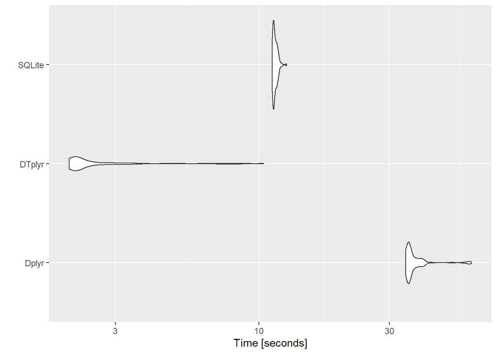

```r
p_load(microbenchmark)
mbm <- readRDS('mbml2.rds')
autoplot(mbm)
```

Plotando o `microbenchmark` realizado 100 vezes, podemos observar que o tempo de execução do código em `dtplyr` é consideravelmente mais rápido se comparado ao tempo de execução com o `dplyr`. Inserindo o `SQLite` no gráfico, percebemos que o `SQLite` aparentemente foi mais lento que o `DTplyr` e mais rápido que o `Dplyr`, porém foi o mais consistente nos tempos de execução.

# Considerações finais:

Este `PDF` é um relatório formatado a fim de entrega do trabalho de forma direta e elegante. Para acesso ao código completo com comentários sobre os processos, favor observar o arquivo *esbocolista2.r* que segue em anexo na entrega.